# You Draw It - Exponential

Emily Robinson

June 2021

# SETUP

- Load libraries
- Functions for computing confidence intervals

```r
library(tidyverse)
library(readr)
library(openssl)
library(mgcv)
library(lme4)
library(tictoc)
`%!in%` = function(x,y) !(x %in% y)
source("gamm-predict-function.R")
```

## EXPONENTIAL DATA

- Note that we have the feedback data (includes x, y- from nls(), and ydrawn).

```r
feedback_smooth  <- read_csv("data/youdrawit-feedback-smooth.csv")

exp_data <- feedback_smooth %>%
  filter(parm_id %!in% c("S", "F", "V", "N")) %>%
  separate(parm_id, into = c("beta", "points_end", "linear"), sep = "-") %>%
  mutate(beta = substr(beta, 5, 8),
         scale = as.factor(ifelse(linear == "true", "Linear", "Log"))) %>%
  select(participantID, nick_name, study_starttime, age, gender, academic_study, recruitment, plotID, start_time, end_time, beta, points_end, scale, x, y, ydrawn, yloess, residualdrawn, residualloess) %>%
  arrange(participantID, x)

factorCols = c('participantID', 'nick_name', 'age', 'gender', 'academic_study', 'recruitment', 'plotID', 'beta', 'points_end', 'scale')
exp_data[,factorCols] <- lapply(exp_data[,factorCols], factor)
# summary(exp_data)
```

# RAW DATA PLOTS

## yloess

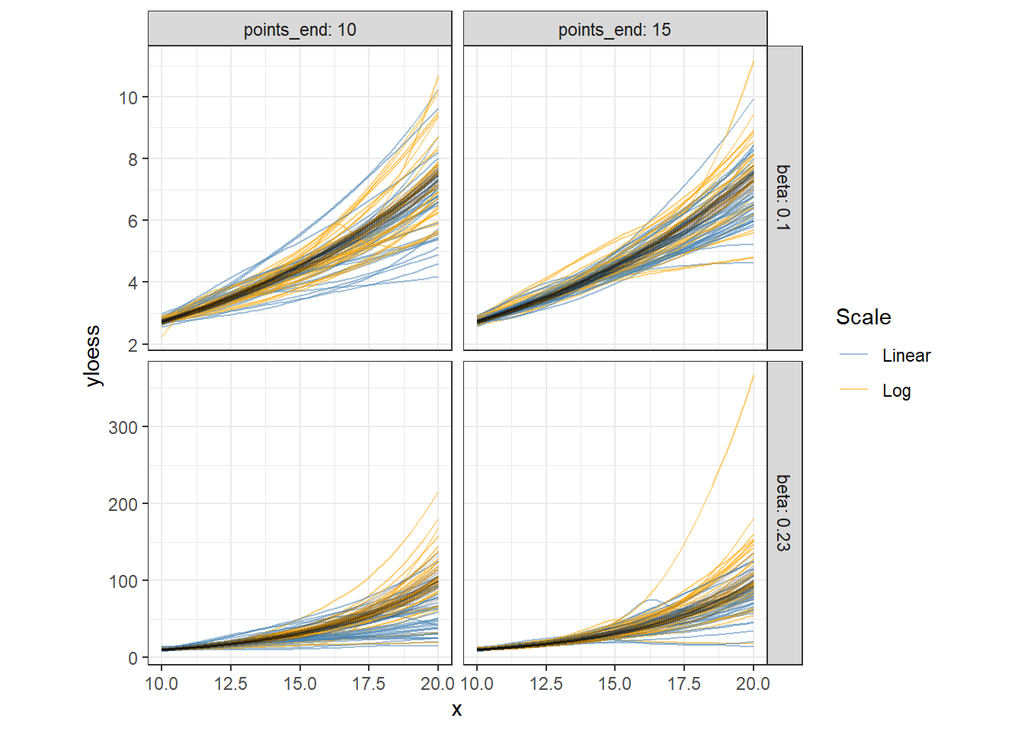

```r
exp_data %>%
  ggplot(aes(x = x)) +
  geom_line(aes(y = yloess, group = plotID, color = scale), alpha = 0.5) +
  geom_line(alpha = 0.1, aes(y = y, group = participantID)) +
  facet_grid(beta ~ points_end, scales = "free", labeller = labeller(beta = label_both, points_end = label_both)) +
  theme_bw() +
  theme(aspect.ratio = 1) +
  scale_color_manual("Scale", values = c("steelblue", "orange")) +
  scale_x_continuous(limits = c(10, 20))
```

# residualloess

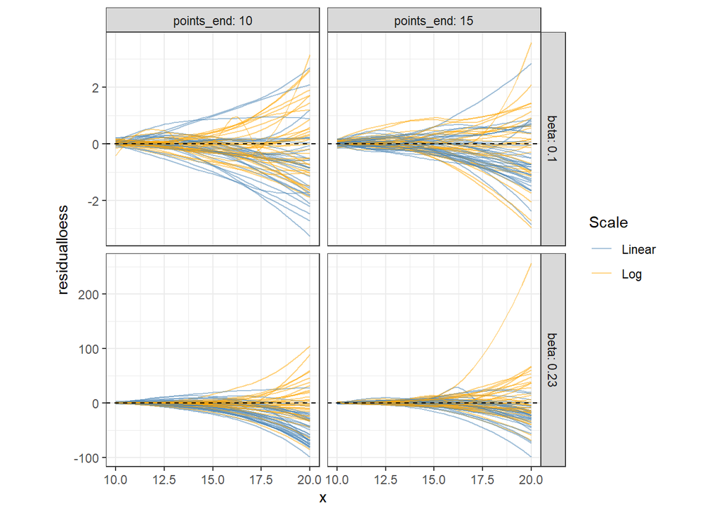

```r
exp_data %>%
  ggplot(aes(x = x)) +
  geom_line(aes(y = residualloess, group = plotID, color = scale), alpha = 0.5) +
  geom_hline(yintercept = 0, linetype = "dashed") +
  facet_grid(beta ~ points_end, scales = "free", labeller = labeller(beta = label_both, points_end = label_both)) +
  theme_bw() +
  theme(aspect.ratio = 1) +
  scale_color_manual("Scale", values = c("steelblue", "orange")) +
  scale_x_continuous(limits = c(10, 20))
```

# GAMM MODELS

**Treatments: 2 x 2 x 2 factorial with a regression over x**

**Response:** raw residuals + residual = ydrawn - ynls, denoted $e_{nls}$

**Experimental Design:**  
+ Each participant saw a total of 8 plots. Each of the 2 data sets (new simulated data for each) on each of the 2 scales and 2 points_end values. In other words, I believe it is a “split plot” design where beta is “applied” to the data set (i.e. beta x participantID) while points_end and scale were “applied” to the plot (i.e. plotID = beta x scale x points_end x participantID).

**ANOVA Table:**

| SV | DF |
| --- | --- |
| participantID | (50 - 1) = 49 |
| beta | (2 - 1) = 1 |
| beta:participantID | (2 - 1)(50 - 1) = 49 |
| points_end | (2 - 1) = 1 |
| scale | (2 - 1) = 1 |
| beta:points_end | (2 - 1)(2 - 1) = 1 |
| beta:scale | (2 - 1)(2 - 1) = 1 |
| points_end:scale | (2 - 1)(2 - 1) = 1 |
| beta:points_end:scale | (2 - 1)(2 - 1)(2 - 1) = 1 |
| beta:points_end:scale:participantID | (50 - 1)(2 + 2 + 2) = 294 |
| x | 1 |
| x:beta | 1 |
| x:points_end | 1 |
| x:scale | 1 |
| x:beta:points_end | 1 |
| x:beta:scale | 1 |
| x:points_end:scale | 1 |
| x:beta:points_end:scale | 1 |
| Autocorrelation? | ? |

**GAMM Model:**

$$y_{drawn} - y_{nls} = e_{ijkl,nls} = \left[\gamma_0 + \beta_i + \rho_j + \delta_k + \beta\rho_{ij} + \beta\delta_{ik} + \rho\delta_{jk} + \beta\rho\delta_{ijk}\right] + \left[s_0(x_{ij}) + s_{\beta_i}(x_{ijkl}) + s_{\rho_j}(x_{ijkl}) + s_{\delta_k}(x_{ijkl}) + s_{\beta\rho_{ij}}(x_{ijkl}) + s_{\beta\delta_{ik}}(x_{ijkl}) + s_{\rho\delta_{jk}}(x_{ijkl}) + s_{\beta\rho\delta_{ijk}}(x_{ijkl}) \right] + p_{l} + \epsilon_{ijkl}$$

- $\gamma_0$ is the overall intercept
- $\beta_i$ is the effect of the beta parameter (i.e. growth) on the intercept
- $\rho_j$ is the effect of the points end choice (10, 15) on the intercept
- $\delta_k$ is the effect of the choice of scale on the intercept
- $\beta\rho_{ij}$ is the effect of the interaction between beta and points end on the intercept
- $\beta\delta_{ik}$ is the effect of the interaction between beta and scale on the intercept
- $\rho\delta_{jk}$ is the effect of the interaction between points end and scale on the intercept
- $\beta\rho\delta_{ijk}$ is the effect of the interaction between beta, points end and scale on the intercept
- $s_0$ is the overall spline equation for x
- $s_{\beta_i}$ is the adjustment to the overall spline equation due to the beta parameter (i.e. growth)
- $s_{\rho_j}$ is the adjustment to the overall spline equation due to the points end choice (10, 15) on the intercept
- $s_{\delta_k}$ is the adjustment to the overall spline equation due to the choice of scale on the intercept
- $s_{\beta\rho_{ij}}$ is the adjustment to the overall spline equation due to the interaction between beta and points end on the intercept
- $s_{\beta\delta_{ik}}$ is the adjustment to the overall spline equation due to the interaction between beta and scale on the intercept
- $s_{\rho\delta_{jk}}$ is the adjustment to the overall spline equation due to the interaction between points end and scale on the intercept
- $s_{\beta\rho\delta_{ijk}}$ is the adjustment to the overall spline equation due to the interaction between beta, points end and scale on the intercept
- $p_{l} \sim N(0, \sigma^2_{participant})$
- $\epsilon_{ijkl} \sim N(0, \sigma^2)$.

## Full model:

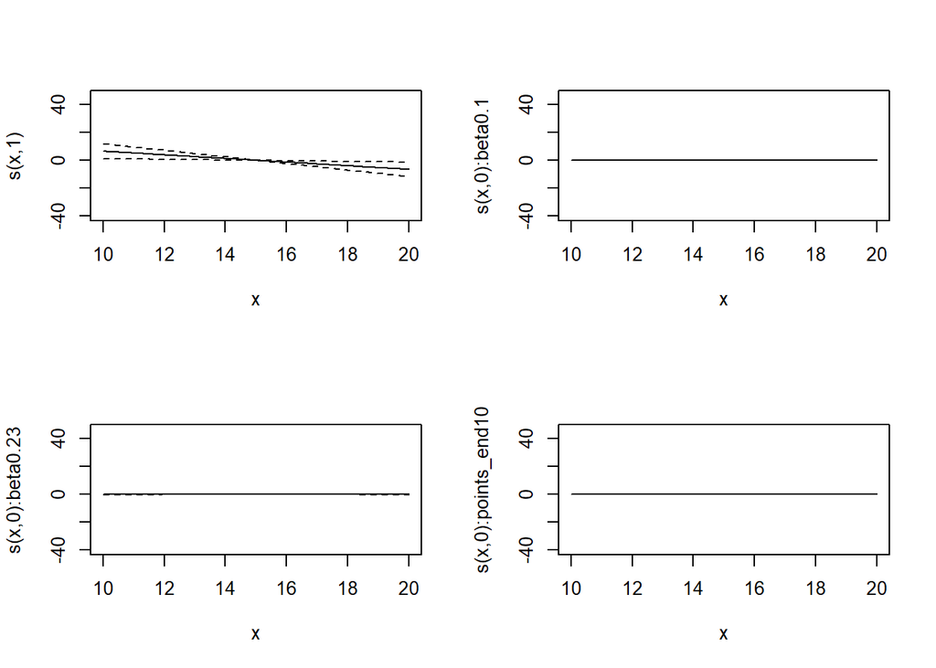

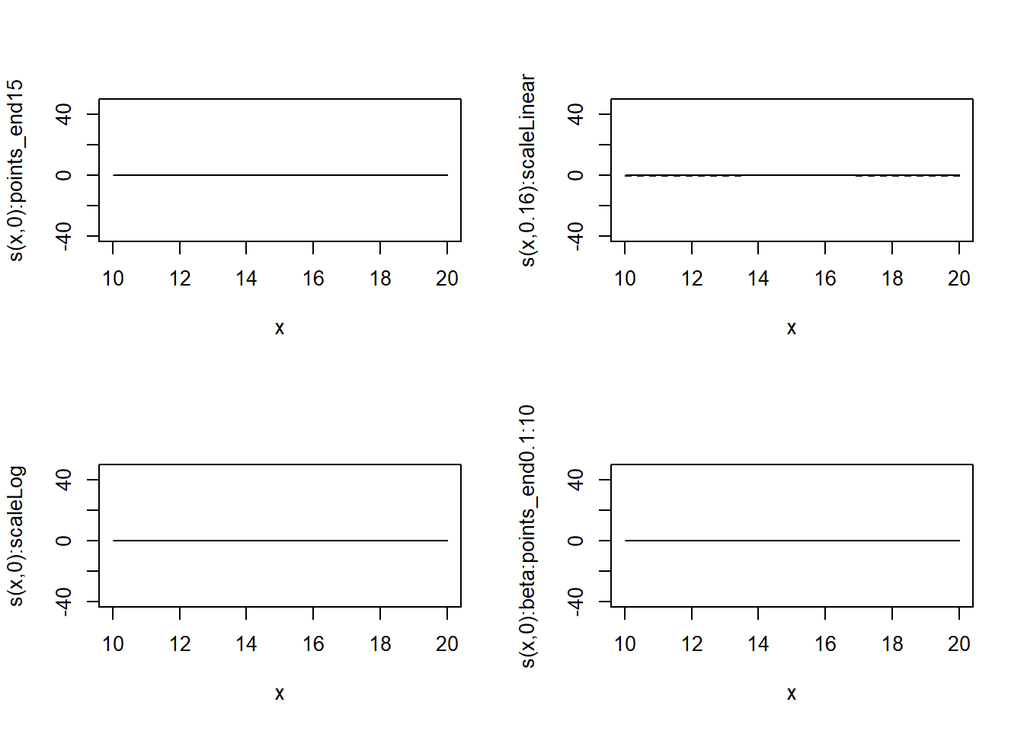

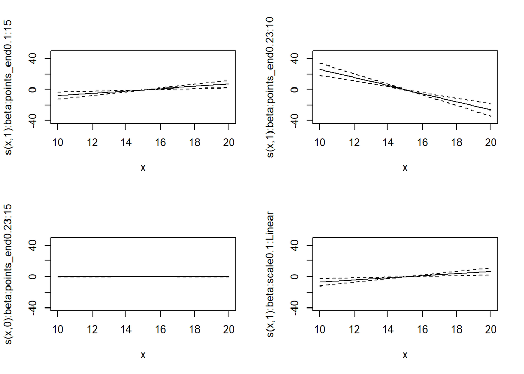

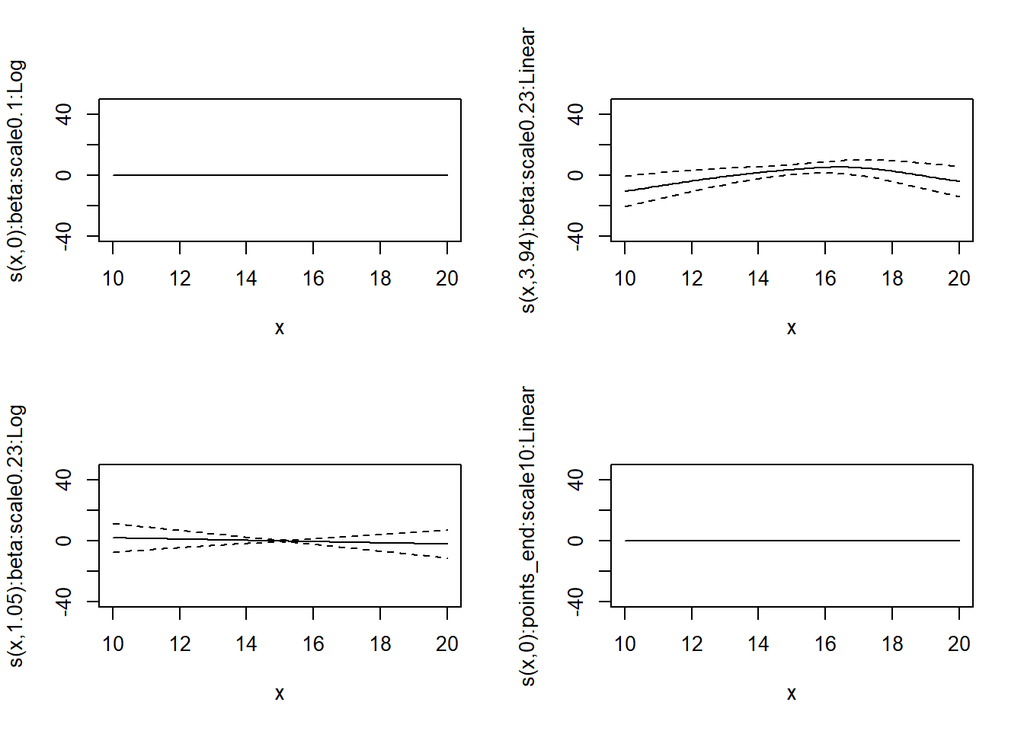

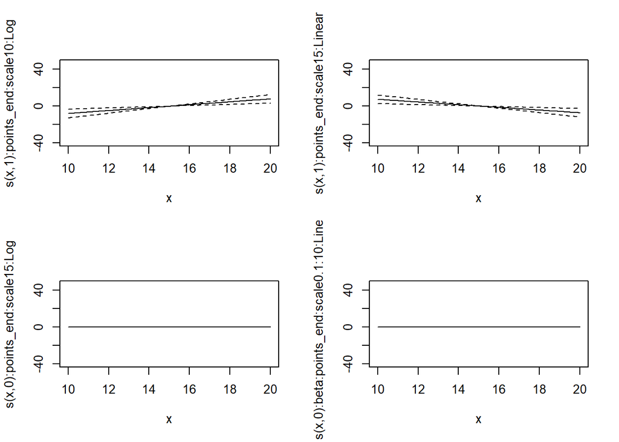

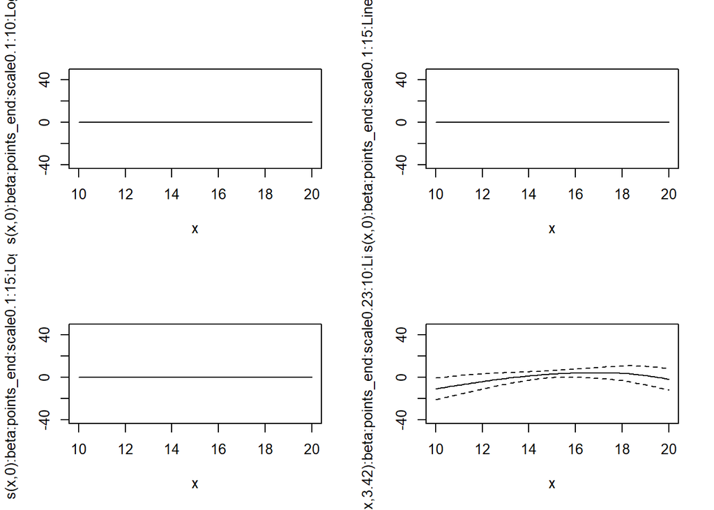

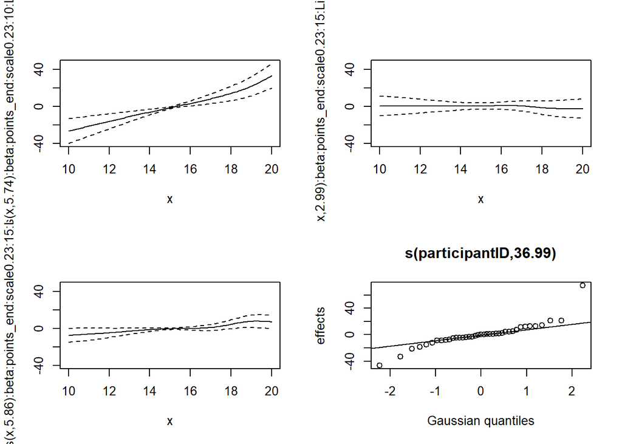

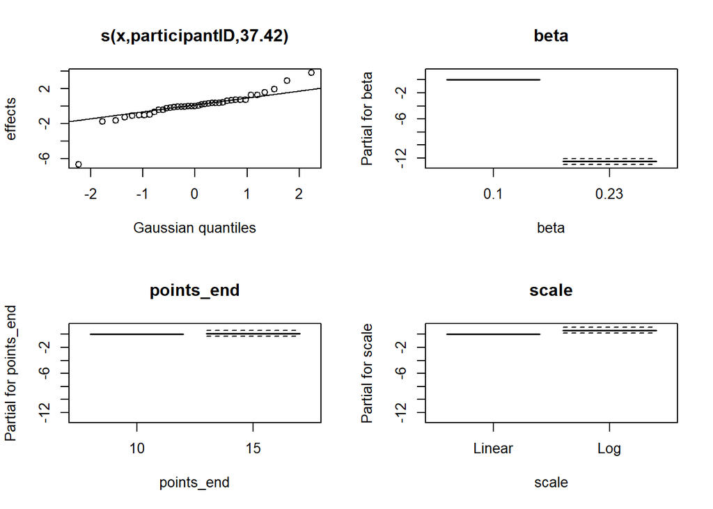

```r
# tic()
exp.gamm.full <- bam(residualdrawn ~ beta*points_end*scale +
                     s(x) +
                     s(x, by = beta) +
                     s(x, by = points_end) +
                     s(x, by = scale) +
                     s(x, by = beta:points_end) +
                     s(x, by = beta:scale) +
                     s(x, by = points_end:scale) +
                     s(x, by = beta:points_end:scale) +
                     s(participantID, bs = "re") +
                     s(x,participantID, bs = "re"),
                     method = "REML",
                     data = exp_data)
plot(exp.gamm.full, pages = 8, all.terms=TRUE)
```

```r
# toc()
# summary(exp.gamm.full)
# anova(exp.gamm.full)

# Obtain Predictions
grid_data.exp.full <- expand_grid(beta = c("0.1", "0.23"),
                         points_end = c("10", "15"),
                         scale = c("Linear", "Log"),
                         x = seq(10,20, 0.5),
                         participantID = exp_data$participantID[1])
preds.exp.full <- predict_gamm(exp.gamm.full, newdata = grid_data.exp.full, se = T, re_form = NA)
grid_data.exp.full$estimate <- preds.exp.full$prediction
grid_data.exp.full$lower <- preds.exp.full$prediction - (1.96 * preds.exp.full$se)
grid_data.exp.full$upper <- preds.exp.full$prediction + (1.96 * preds.exp.full$se)
# head(grid_data.exp.full)
```

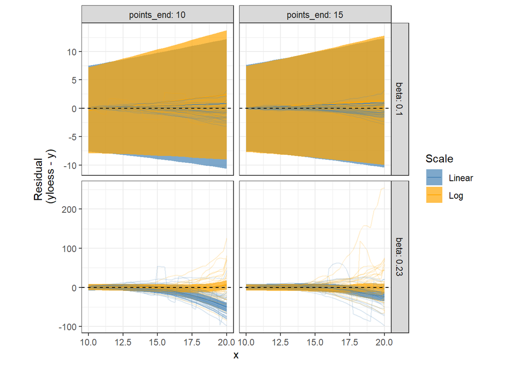

```r
# Plot Predictions
grid_data.exp.full %>%
  ggplot(aes(x = x, y = estimate, group = scale, color = scale, fill = scale)) +
  geom_ribbon(aes(ymin = lower, ymax = upper), color = NA, alpha = 0.7) +
  geom_line() +
  geom_line(data = exp_data, aes(x = x, y = residualdrawn, group = plotID), alpha = 0.2) +
  geom_hline(yintercept = 0, linetype = "dashed") +
  facet_grid(beta ~ points_end, scales = "free", labeller = labeller(beta = label_both, points_end = label_both)) +
  theme_bw() +
  theme(aspect.ratio = 1) +
  scale_y_continuous("Residual \n (yloess - y)") +
  scale_color_manual("Scale", values = c("steelblue", "orange")) +
  scale_fill_manual("Scale", values = c("steelblue", "orange"))
```

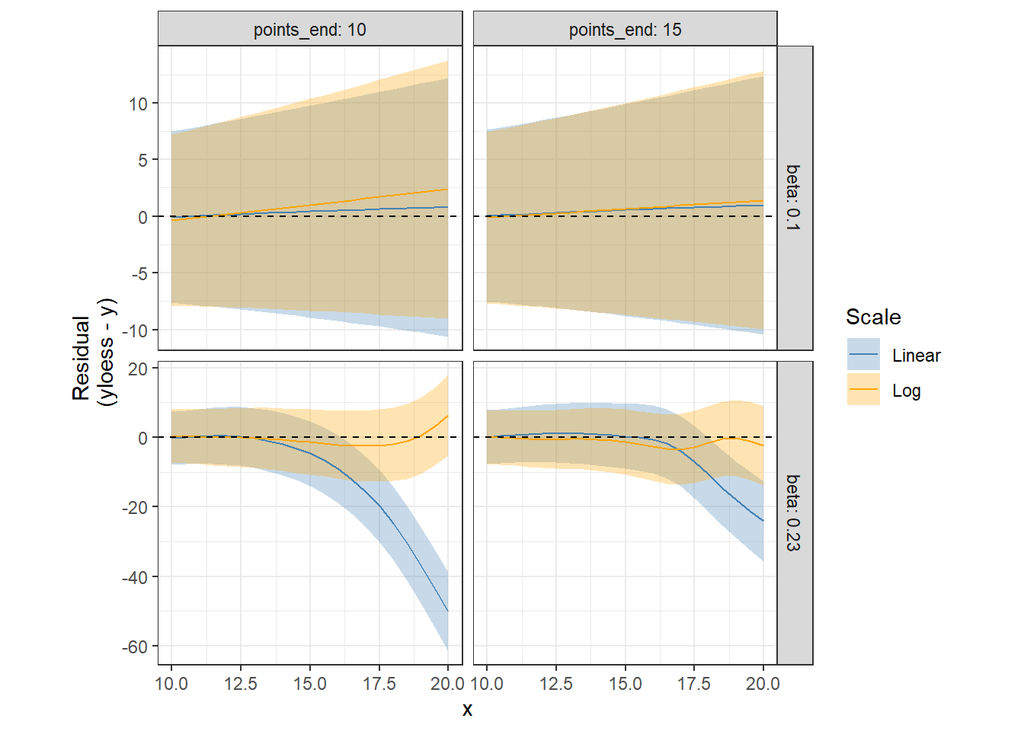

```r
# Plot Predictions
grid_data.exp.full %>%
  ggplot(aes(x = x, y = estimate, group = scale, color = scale, fill = scale)) +
  geom_ribbon(aes(ymin = lower, ymax = upper), color = NA, alpha = 0.3) +
  geom_line() +
  # geom_line(data = exp_data, aes(x = x, y = residualdrawn, group = plotID), alpha = 0.2) +
  geom_hline(yintercept = 0, linetype = "dashed") +
  facet_grid(beta ~ points_end, scales = "free", labeller = labeller(beta = label_both, points_end = label_both)) +
  theme_bw() +
  theme(aspect.ratio = 1) +
  scale_y_continuous("Residual \n (yloess - y)") +
  scale_color_manual("Scale", values = c("steelblue", "orange")) +
  scale_fill_manual("Scale", values = c("steelblue", "orange"))
```

## Condensed model:

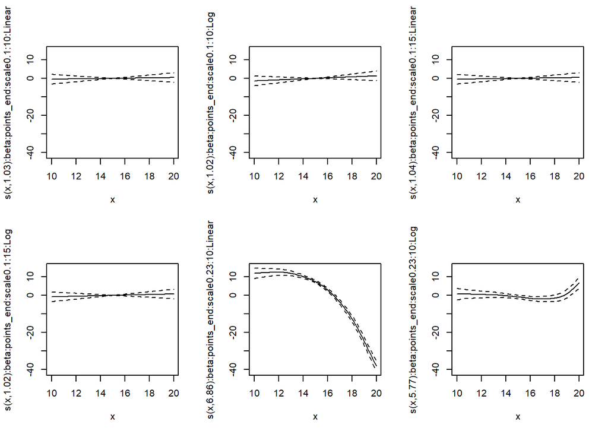

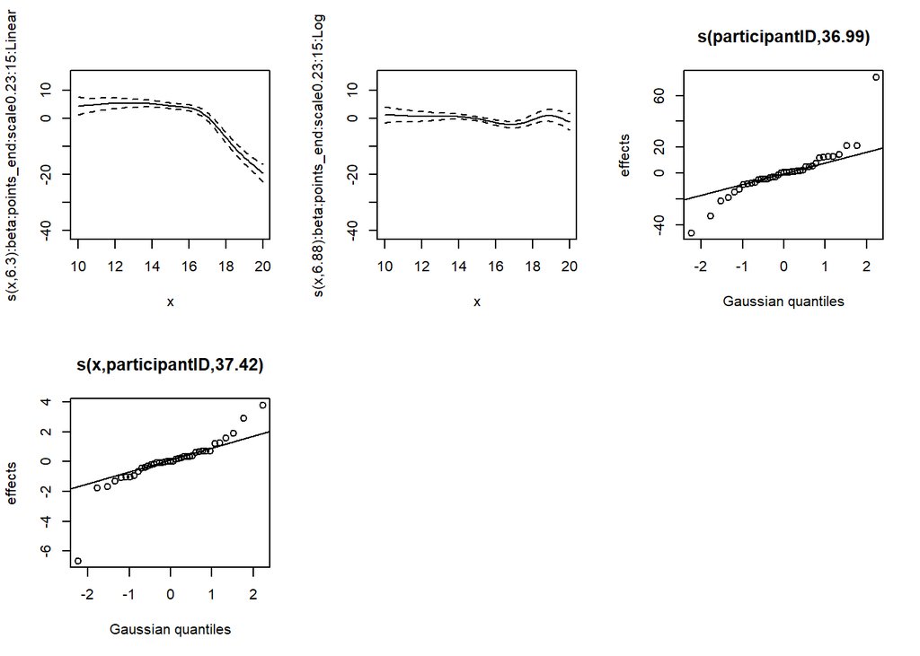

```r
#tick()
exp.gamm.reduced <- bam(residualdrawn ~ -1 + beta:points_end:scale +
                        s(x, by = beta:points_end:scale) +
                        s(participantID, bs = "re") +
                        s(x,participantID, bs = "re"),
                        method = "REML",
                        data = exp_data)
plot(exp.gamm.reduced, pages = 2,all.terms=TRUE)
```

```r
# toc()
# summary(exp.gamm.reduced)
# anova(exp.gamm.reduced)

# Obtain Predictions
grid_data.exp.reduced <- expand_grid(beta = c("0.1", "0.23"),
                         points_end = c("10", "15"),
                         scale = c("Linear", "Log"),
                         x = seq(10,20, 0.5),
                         participantID = exp_data$participantID[1])
preds.exp.reduced <- predict_gamm(exp.gamm.reduced, newdata = grid_data.exp.reduced, se = T, re_form = NA)
grid_data.exp.reduced$estimate <- preds.exp.reduced$prediction
grid_data.exp.reduced$lower <- preds.exp.reduced$prediction - (1.96 * preds.exp.reduced$se)
grid_data.exp.reduced$upper <- preds.exp.reduced$prediction + (1.96 * preds.exp.reduced$se)
# head(grid_data.exp.reduced)
```

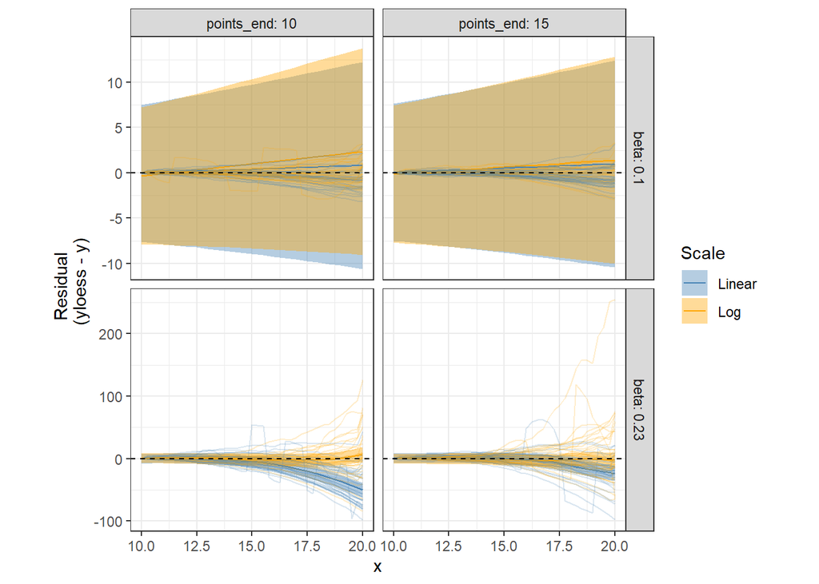

```r
# Plot Predictions
grid_data.exp.reduced %>%
  ggplot(aes(x = x, y = estimate, group = scale, color = scale, fill = scale)) +
  geom_ribbon(aes(ymin = lower, ymax = upper), color = NA, alpha = 0.4) +
  geom_line() +
  geom_line(data = exp_data, aes(x = x, y = residualdrawn, group = plotID), alpha = 0.2) +
  geom_hline(yintercept = 0, linetype = "dashed") +
  facet_grid(beta ~ points_end, scales = "free", labeller = labeller(beta = label_both, points_end = label_both)) +
  theme_bw() +
  theme(aspect.ratio = 1) +
  scale_y_continuous("Residual \n (yloess - y)") +
  scale_color_manual("Scale", values = c("steelblue", "orange")) +
  scale_fill_manual("Scale", values = c("steelblue", "orange"))
```

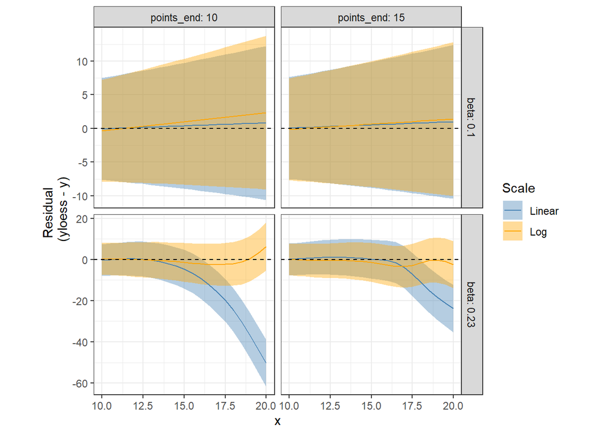

```r
# Plot Predictions
grid_data.exp.reduced %>%
  ggplot(aes(x = x, y = estimate, group = scale, color = scale, fill = scale)) +
  geom_ribbon(aes(ymin = lower, ymax = upper), color = NA, alpha = 0.4) +
  geom_line() +
  # geom_line(data = exp_data, aes(x = x, y = residualdrawn, group = plotID), alpha = 0.2) +
  geom_hline(yintercept = 0, linetype = "dashed") +
  facet_grid(beta ~ points_end, scales = "free", labeller = labeller(beta = label_both, points_end = label_both)) +
  theme_bw() +
  theme(aspect.ratio = 1) +
  scale_y_continuous("Residual \n (yloess - y)") +
  scale_color_manual("Scale", values = c("steelblue", "orange")) +
  scale_fill_manual("Scale", values = c("steelblue", "orange"))
```